# Introductions

01-13-2026

## Agenda

1. Introduction
2. Goals and Expectations
3. Semester Overview: Milestones and Deliverables
4. Grading and Assessment
5. Code of Conduct: Importance and Development
6. V-Model Phases and Project Items
7. Configuration Items (CI) → Project Charter

## Instructors

Course Instructors

## What is The Most Important Thing?

- **In life**, the most important thing is **subjective**.
- **Primary dimensions**:

  Health, Love & Relationships, Purpose & Meaning, Gratitude, Freedom, Learning & Growth, Self-Care.
- This **set of dimensions** makes a conceptual **backbone for our capstone**, because it positions the course not as a technical culminating experience, but as a **professional and personal transition course.**

[figure not shown]

## The Bridge Between Academic Training and Life (After Graduation)

- Learn to **go beyond** working your team’s project,  
  develop the ability to **work in any project!**
- Others may always outpace you in **technical expertise**.
- Your true advantage is **systems thinking**, an advantage that reaches its full power when paired with **strong communication!**

[figure not shown]

## Course

- **Capstone Design** class represents the culmination of an educational journey.
- It’s where **theory** meets **practice**,  
  **abstraction** meets **reality**, and the **individual student** transitions from **learning concepts** to **creating, evaluating, and owning** a complete system.

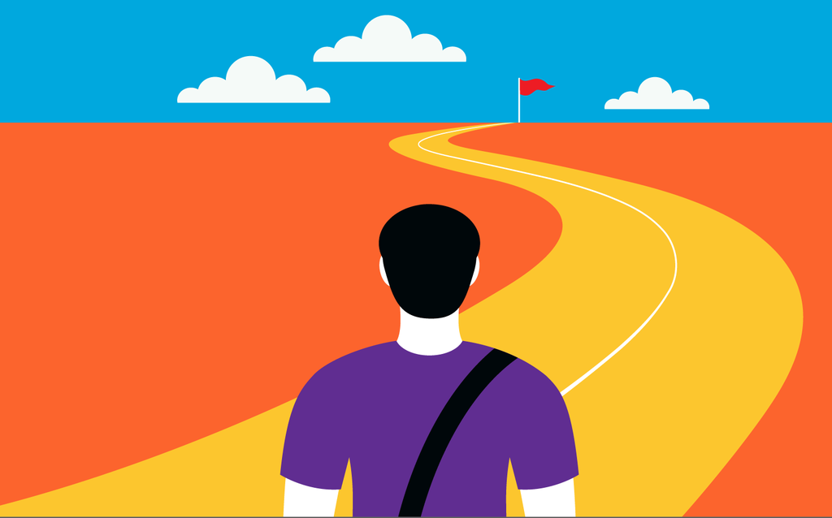

## Goals

- **Apply** Data Engineering Knowledge
- **Develop** End-to-End Project Skills
  - **Plan**, **document**, **execute** projects using a structured framework (i.e., V-Model).
- Foster **Collaboration** & **Professional Skills**
- Strengthen **Problem-Solving** & **Critical Thinking**
- **Prepare** for Industry and Research
  - Build a portfolio demonstrating technical and teamwork skills,
  - Experience working under professional expectations.

## ISEN Mission Statement

**To serve** the state, nation and global community by educating industrial engineering students to be well founded in engineering fundamentals and **to have the knowledge and skills** required **to design, develop, improve, implement and control** sophisticated production and service **systems** in an environment characterized by **complex technical and social challenges**. Throughout this educational process, students will be instilled with the **highest standards of professional and ethical behavior**.

[figure not shown]

## Expectations

- Active Participation
- Ownership and Accountability
- Professional Communication
- Quality and Documentation
- Ethical Conduct

## Professional Standards of Conduct

Professional Standards of Conduct

## Attendance

Attendance

## Confidentiality and Non-attribution

Confidentiality and Non-attribution

## Faculty Advisor

Faculty Advisor

## Sponsors

Sponsors

## Milestones

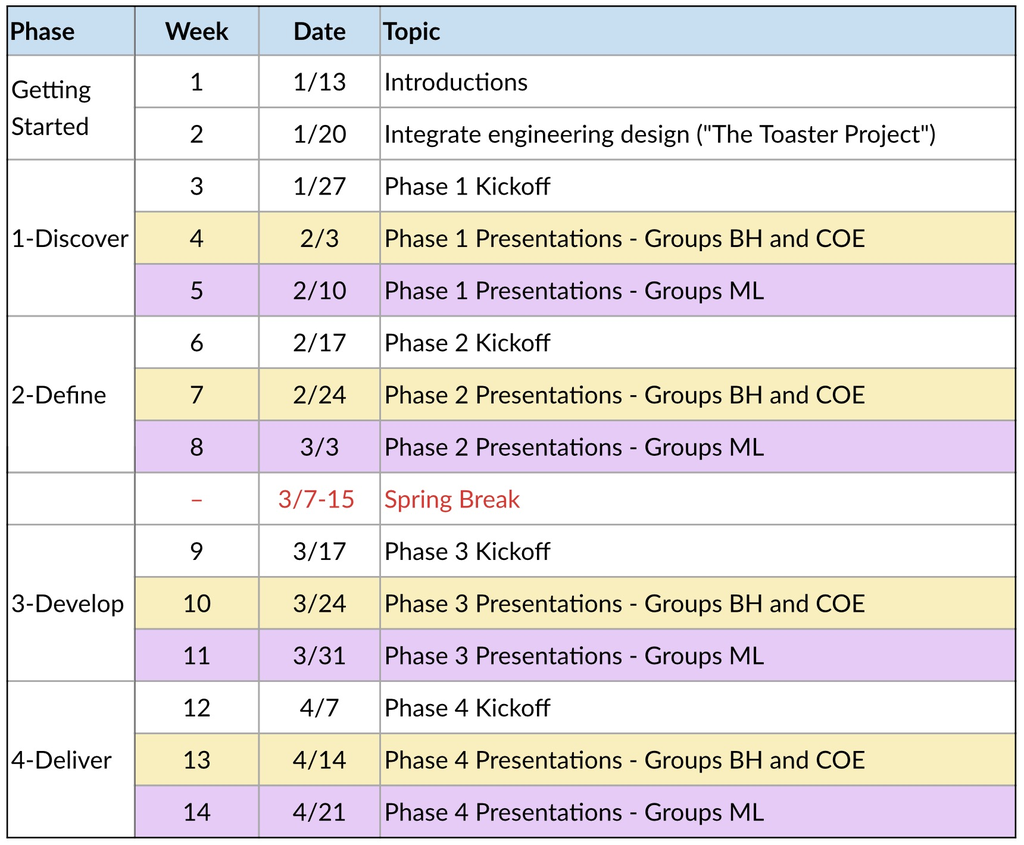

## Deliverables

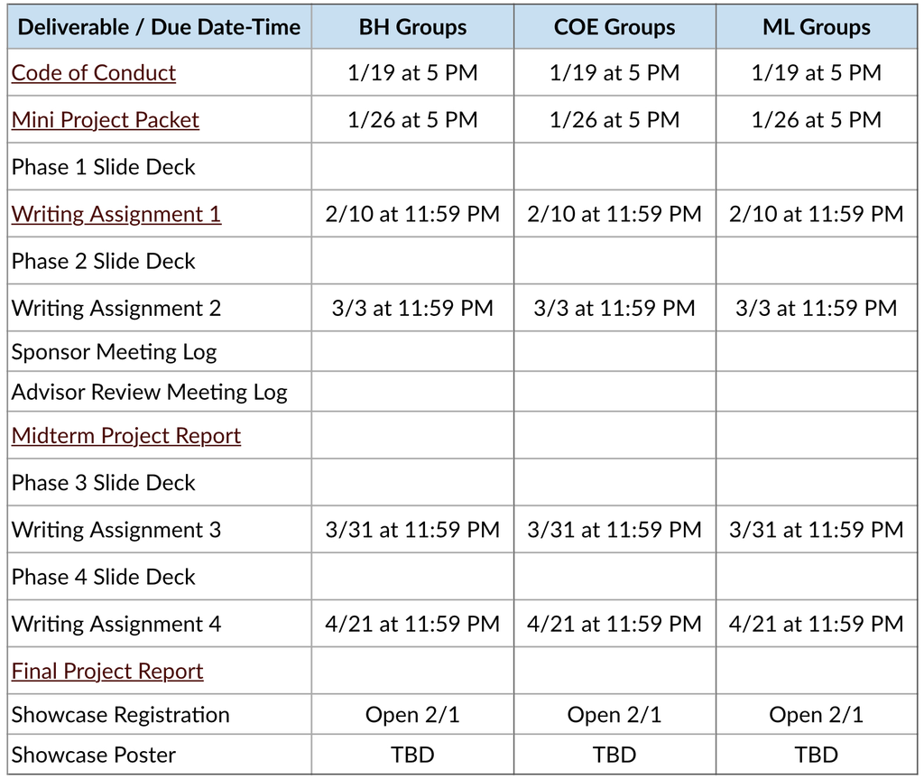

## Grading and Assessment

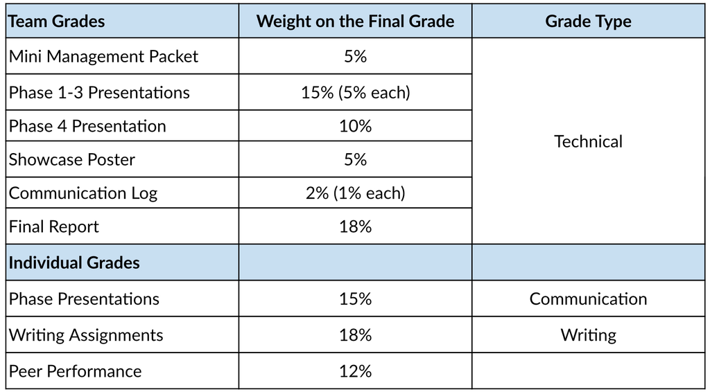

## Team Work?

[figure not shown]

## Team Work

- In industry, project failure is rarely caused by lack of technical skill. Most often caused by:
  - Unclear expectations,
  - Poor communication,
  - Uneven workload distribution,
  - Missed deadlines,
  - Unresolved conflict,
  - Unprofessional behavior.

## Social Loafing

Social Loafing

## Code of Conduct

- Let us prevent these problems before they occur.
- Due 1/19 at 5 PM
- On Canvas: https://canvas.tamu.edu/courses/431435/assignments/2874310

## V-Model

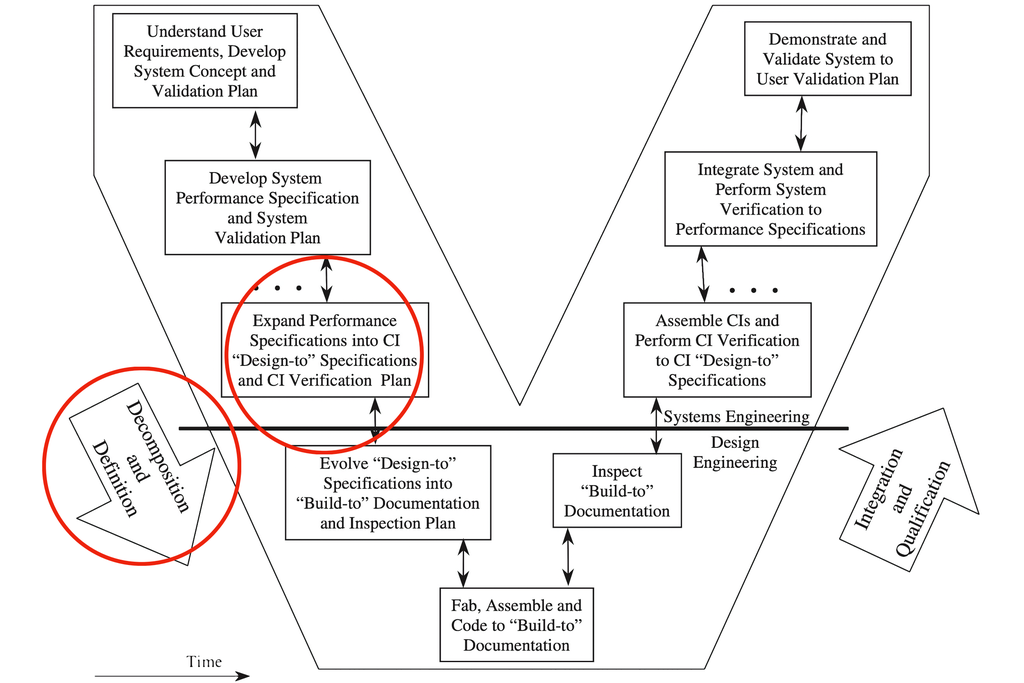

## What is a Configuration Item (CI)?

- A CI is any **hardware, software, firmware, document, or combination** thereof that is:
  - Individually identifiable,
  - Formally baselined,
  - Controlled under configuration management,
  - Verified against approved specifications.
- In other words, a CI is anything the organization has decided must be **controlled, versioned, and verified** as its own official product element.

## What is a Configuration Item (CI)?

- In data engineering, a CI is:

  Any version-controlled,  
  independently testable,  
  production-quality component  
  of a data system that has formal requirements,  
  formal tests, and formal approval.
- A CI is no longer “just a file”, it becomes a **certified system component**.

## What Counts as a CI in a Data Platform

| CI Area | Examples |
| --- | --- |
| Sources | Ingest schema, API feed |
| Pipelines | ETL job, stream proc |
| Storage | Warehouse schema, lakehouse |
| Code | Feature lib, validation |
| Models | Forecast, classifier |
| Orchestration | Airflow DAG, dbt |
| Interfaces | API, data contracts |
| Governance | Quality rules, PII mask |
| Docs | Data dict, lineage |

## Project Charter Adjustments

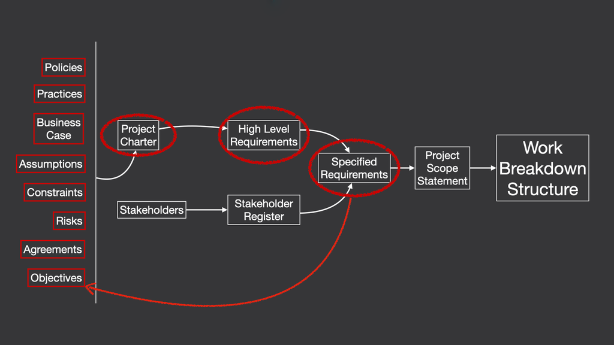

## Mini Project Packet

## Purpose

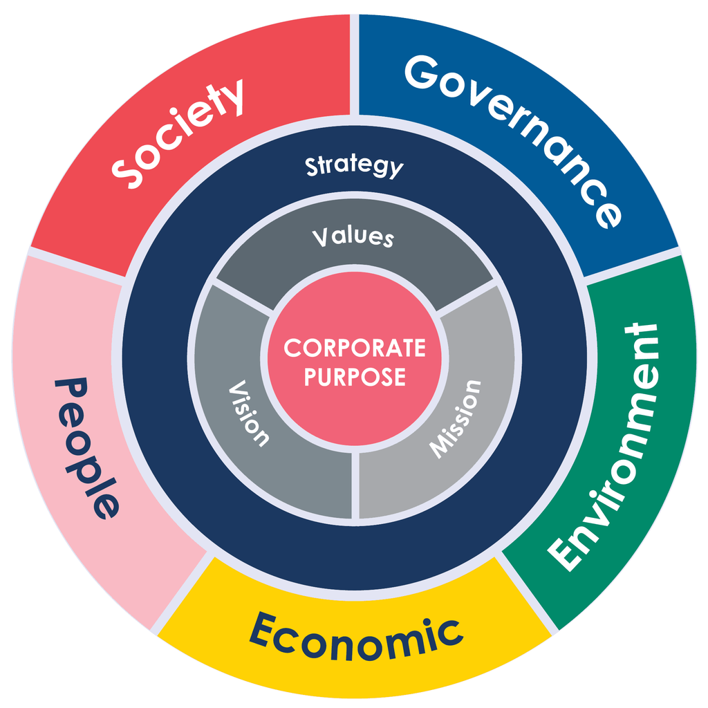

## SE and PM Integration

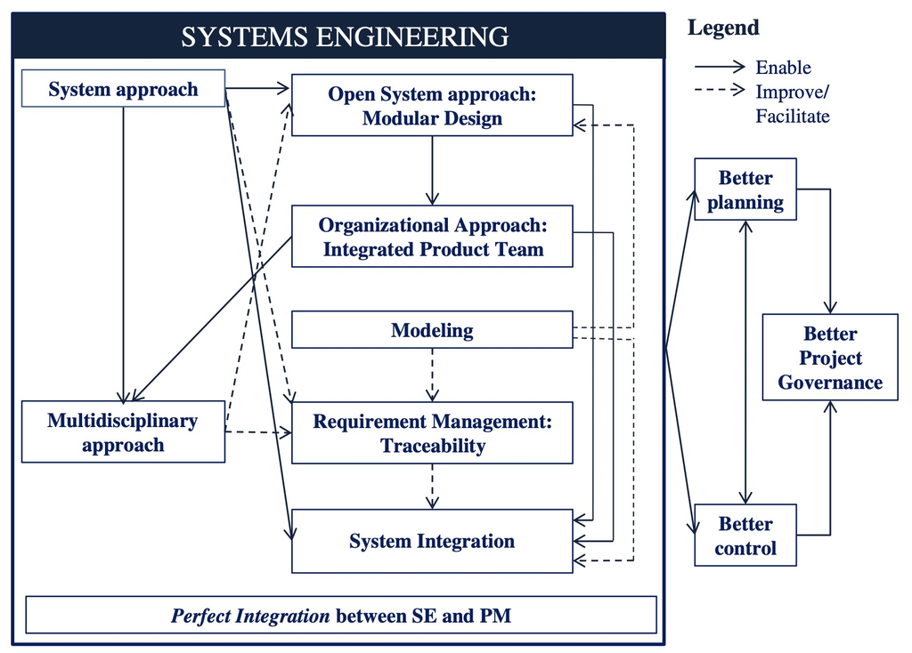

## Gantt Chart

Gantt Chart

## SE Standards

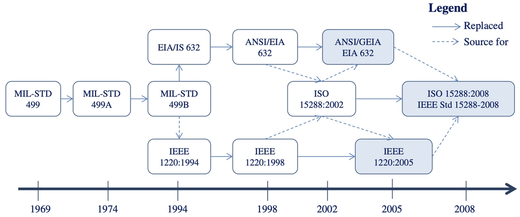